# Background

Renewable energy sources play an increasingly important role in the global energy mix, as the effort to reduce the environmental impact of energy production increases.

Out of all the renewable energy alternatives, wind energy is one of the most developed technologies worldwide. The U.S Department of Energy has put together a guide to achieving operational efficiency using predictive maintenance practices.

Predictive maintenance uses sensor information and analysis methods to measure and predict degradation and future component capability. The idea behind predictive maintenance is that failure patterns are predictable and if component failure can be predicted accurately and the component is replaced before it fails, the costs of operation and maintenance will be much lower.

The sensors fitted across different machines involved in the process of energy generation collect data related to various environmental factors (temperature, humidity, wind speed, etc.) and additional features related to various parts of the wind turbine (gearbox, tower, blades, break, etc.).

# Objective

“ReneWind” is a company working on improving the machinery/processes involved in the production of wind energy using machine learning and has collected data of generator failure of wind turbines using sensors. They have shared a ciphered version of the data, as the data collected through sensors is confidential (the type of data collected varies with companies). Data has 40 predictors, 40000 observations in the training set and 10000 in the test set.

The objective is to build various classification models, tune them and find the best one that will help identify failures so that the generator could be repaired before failing/breaking and the overall maintenance cost of the generators can be brought down.

“1” in the target variables should be considered as “failure” and “0” will represent “No failure”.

The nature of predictions made by the classification model will translate as follows:

True positives (TP) are failures correctly predicted by the model. False negatives (FN) are real failures in the generator of wind turbine where there is no detection by the model. False positives (FP) are failure detections in the generator of the wind turbine where actually there is no failure. So, the maintenance cost associated with the model would be:

Maintenance cost = TP*(Repair cost) + FN*(Replacement cost) + FP*(Inspection cost) where,

Replacement cost = $40,000 Repair cost = $15,000 Inspection cost = $5,000 Here the objective is to reduce the maintenance cost so, we want a metric that could reduce the maintenance cost.

The minimum possible maintenance cost = Actual failures*(Repair cost) = (TP + FN)*(Repair cost)

And the maintenance cost associated with model = TP*(Repair cost) + FN*(Replacement cost) + FP*(Inspection cost)

So, we will try to maximize the ratio of minimum possible maintenance cost and the maintenance cost associated with the model.

The value of this ratio will lie between 0 and 1, the ratio will be 1 only when the maintenance cost associated with the model will be equal to the minimum possible maintenance cost.

## Key Questions

```python
# import the important packages
import pandas as pd
# library used for data manipulation and analysis

import numpy as np  # library used for working with arrays

import matplotlib.pyplot as plt  # library for visualization

import seaborn as sns  # library for visualization

%matplotlib inline

import scipy.stats as stats  # this library contains a large number of probability distributions as well as a growing library of statistical functions
from scipy.stats import uniform
from scipy.stats import norm
from scipy.stats import expon
from scipy.stats import binom
from scipy.stats import ttest_1samp
from scipy.stats import ttest_ind
from scipy.stats import ttest_rel
from statsmodels.stats.proportion import proportions_ztest
from scipy.stats import chi2
from scipy.stats import f
from scipy.stats import chi2_contingency
from scipy.stats import levene
from scipy.stats import f_oneway
from statsmodels.stats.multicomp import pairwise_tukeyhsd
import pylab
import scipy.stats as stats
import statsmodels.stats.api as sms
from statsmodels.compat import lzip


from sklearn.linear_model import LinearRegression
from sklearn.model_selection import train_test_split #sklearn package's randomized data splitting function
from sklearn.preprocessing import PolynomialFeatures
from sklearn import linear_model
from sklearn.metrics import mean_squared_error
import statsmodels.api as sm
from sklearn.metrics import mean_absolute_error, mean_squared_error, r2_score
from sklearn.tree import DecisionTreeClassifier
from sklearn import tree
from sklearn.linear_model import LogisticRegression
from sklearn import metrics
from sklearn.tree import DecisionTreeClassifier
from sklearn import tree
from sklearn.model_selection import GridSearchCV,RandomizedSearchCV
from sklearn.ensemble import BaggingClassifier
from sklearn.ensemble import RandomForestClassifier
from sklearn.metrics import roc_auc_score
from sklearn.metrics import confusion_matrix, classification_report
from sklearn.metrics import accuracy_score,precision_score,recall_score,f1_score
from sklearn.ensemble import AdaBoostClassifier, GradientBoostingClassifier
!pip install xgboost
from xgboost import XGBClassifier
from sklearn.metrics import recall_score


pd.set_option('display.max_columns',None)
pd.set_option('display.max_rows',200)

#Let us break the X and y dataframes into training set and test set. For this we will use
#Sklearn package's data splitting function which is based on random function

# To tune model, get different metric scores and split data
from sklearn.model_selection import GridSearchCV
from sklearn.model_selection import train_test_split, StratifiedKFold, cross_val_score
from sklearn.metrics import (
    f1_score,
    accuracy_score,
    recall_score,
    precision_score,
    confusion_matrix,
    roc_auc_score,
    plot_confusion_matrix,
)

# To impute missing values
from sklearn.impute import KNNImputer
from sklearn.impute import SimpleImputer

# To build a logistic regression model
from sklearn.linear_model import LogisticRegression

# To oversample and undersample data
!pip install imbalanced-learn
from imblearn.over_sampling import SMOTE
from imblearn.under_sampling import RandomUnderSampler

# To be used for creating pipelines and personalizing them
from sklearn.pipeline import Pipeline
from sklearn.compose import ColumnTransformer

# calculate accuracy measures and confusion matrix
from sklearn import metrics

# To supress warnings
import warnings

warnings.filterwarnings("ignore")
```

```python
book = pd.read_csv('Train.csv')
book.head(10)
```

|  | V1 | V2 | V3 | V4 | V5 | V6 | V7 | V8 | V9 | V10 | V11 | V12 | V13 | V14 | V15 | V16 | V17 | V18 | V19 | V20 | V21 | V22 | V23 | V24 | V25 | V26 | V27 | V28 | V29 | … |
| --- | --- | --- | --- | --- | --- | --- | --- | --- | --- | --- | --- | --- | --- | --- | --- | --- | --- | --- | --- | --- | --- | --- | --- | --- | --- | --- | --- | --- | --- | --- |
| 0 | -4.464606 | -4.679129 | 3.101546 | 0.506130 | -0.221083 | -2.032511 | -2.910870 | 0.050714 | -1.522351 | 3.761892 | -5.714719 | 0.735893 | 0.981251 | 1.417884 | -3.375815 | -3.047303 | 0.306194 | 2.914097 | 2.269979 | 4.394876 | -2.388299 | 0.646388 | -1.190508 | 3.132986 | 0.665277 | -2.510846 | -0.036744 | 0.726218 | -3.982187 | … |
| 1 | -2.909996 | -2.568662 | 4.109032 | 1.316672 | -1.620594 | -3.827212 | -1.616970 | 0.669006 | 0.387045 | 0.853814 | -6.352826 | 4.271718 | 3.162020 | 0.257559 | -3.547127 | -4.284533 | 2.897271 | 1.508313 | 3.667963 | 7.123824 | -4.095749 | 1.015082 | -0.969790 | -0.968207 | 2.063871 | -1.646110 | 0.426956 | 0.734860 | -4.470201 | … |
| 2 | 4.283674 | 5.105381 | 6.092238 | 2.639922 | -1.041357 | 1.308419 | -1.876140 | -9.582412 | 3.469504 | 0.763395 | -2.573231 | -3.349664 | -0.594666 | -5.246841 | -4.309957 | -16.232431 | -0.999690 | 2.318208 | 5.941888 | -3.857972 | -11.599497 | 4.021252 | -6.281194 | 4.633167 | 0.930157 | 6.280225 | 0.850654 | 0.268846 | -2.206445 | … |
| 3 | 3.365912 | 3.653381 | 0.909671 | -1.367528 | 0.332016 | 2.358938 | 0.732600 | -4.332135 | 0.565695 | -0.101080 | 1.914465 | -0.951458 | -1.255259 | -2.706522 | 0.193223 | -4.769379 | -2.205319 | 0.907716 | 0.756894 | -5.833678 | -3.065122 | 1.596647 | -1.757311 | 1.766444 | -0.267098 | 3.625036 | 1.500346 | -0.585712 | 0.783034 | … |
| 4 | -3.831843 | -5.824444 | 0.634031 | -2.418815 | -1.773827 | 1.016824 | -2.098941 | -3.173204 | -2.081860 | 5.392621 | -0.770673 | 1.106718 | 1.144261 | 0.943301 | -3.163804 | -4.247825 | -4.038909 | 3.688534 | 3.311196 | 1.059002 | -2.143026 | 1.650120 | -1.660592 | 1.679910 | -0.450782 | -4.550695 | 3.738779 | 1.134404 | -2.033531 | … |
| 5 | 1.618098 | 1.888342 | 7.046143 | -1.147285 | 0.083080 | -1.529780 | 0.207309 | -2.493629 | 0.344926 | 2.118578 | -3.053023 | 0.459719 | 2.704527 | -0.636086 | -0.453717 | -3.174046 | -3.404347 | -1.281536 | 1.582104 | -1.951778 | -3.516555 | -1.206011 | -5.627854 | -1.817653 | 2.124142 | 5.294642 | 4.748137 | -2.308536 | -3.962977 | … |
| 6 | -0.111440 | 3.872488 | -3.758361 | -2.982897 | 3.792714 | 0.544960 | 0.205433 | 4.848994 | -1.854920 | -6.220023 | 1.998347 | 4.723757 | 0.709113 | -1.989432 | -2.632684 | 4.184447 | 2.245356 | 3.734452 | -6.312766 | -5.379918 | -0.886667 | 2.061694 | 9.445586 | 4.489976 | -3.945144 | 4.582065 | -8.780422 | -3.382967 | 5.106507 | … |
| 7 | 0.159623 | -4.233781 | -0.264310 | -5.477119 | -0.190854 | -0.356274 | -0.134486 | 4.066608 | -3.858569 | 1.692441 | 0.137901 | 3.974719 | 0.672853 | 1.878144 | 0.764158 | 4.235913 | -2.129272 | 2.348465 | -2.147454 | -0.982376 | 0.386345 | 1.010637 | 3.418654 | 0.996017 | 0.060580 | -3.036740 | 1.787573 | -1.726537 | 0.307837 | … |
| 8 | -3.644913 | -1.040955 | 2.425282 | 1.465421 | -0.421516 | -1.515841 | -0.955096 | 1.160726 | -2.023863 | 1.212668 | -0.148411 | 2.617059 | 0.939038 | -0.699744 | -1.601142 | 1.007142 | -0.795601 | -0.816698 | 3.541179 | 1.063903 | -0.984179 | -1.400323 | -1.364278 | 1.688099 | -1.626152 | 0.552885 | -2.372348 | -0.185127 | 1.243529 | … |
| 9 | -0.184565 | -4.721470 | 0.864988 | -3.078695 | -2.226888 | -1.282220 | -0.804717 | 3.289733 | -1.567971 | 0.749904 | 0.528830 | 3.220564 | 2.945183 | 1.724073 | -0.923123 | 2.534830 | -1.696713 | 0.677068 | -0.246087 | 2.747678 | -1.165392 | 0.247621 | 1.160684 | -2.850139 | 0.503405 | -3.532215 | 1.861243 | -1.465354 | 0.873767 | … |

```python
book.shape
```

```
(40000, 41)
```

```python
book_Test = pd.read_csv('Test.csv')
book.head(10)
```

|  | V1 | V2 | V3 | V4 | V5 | V6 | V7 | V8 | V9 | V10 | V11 | V12 | V13 | V14 | V15 | V16 | V17 | V18 | V19 | V20 | V21 | V22 | V23 | V24 | V25 | V26 | V27 | V28 | V29 | … |
| --- | --- | --- | --- | --- | --- | --- | --- | --- | --- | --- | --- | --- | --- | --- | --- | --- | --- | --- | --- | --- | --- | --- | --- | --- | --- | --- | --- | --- | --- | --- |
| 0 | -4.464606 | -4.679129 | 3.101546 | 0.506130 | -0.221083 | -2.032511 | -2.910870 | 0.050714 | -1.522351 | 3.761892 | -5.714719 | 0.735893 | 0.981251 | 1.417884 | -3.375815 | -3.047303 | 0.306194 | 2.914097 | 2.269979 | 4.394876 | -2.388299 | 0.646388 | -1.190508 | 3.132986 | 0.665277 | -2.510846 | -0.036744 | 0.726218 | -3.982187 | … |
| 1 | -2.909996 | -2.568662 | 4.109032 | 1.316672 | -1.620594 | -3.827212 | -1.616970 | 0.669006 | 0.387045 | 0.853814 | -6.352826 | 4.271718 | 3.162020 | 0.257559 | -3.547127 | -4.284533 | 2.897271 | 1.508313 | 3.667963 | 7.123824 | -4.095749 | 1.015082 | -0.969790 | -0.968207 | 2.063871 | -1.646110 | 0.426956 | 0.734860 | -4.470201 | … |
| 2 | 4.283674 | 5.105381 | 6.092238 | 2.639922 | -1.041357 | 1.308419 | -1.876140 | -9.582412 | 3.469504 | 0.763395 | -2.573231 | -3.349664 | -0.594666 | -5.246841 | -4.309957 | -16.232431 | -0.999690 | 2.318208 | 5.941888 | -3.857972 | -11.599497 | 4.021252 | -6.281194 | 4.633167 | 0.930157 | 6.280225 | 0.850654 | 0.268846 | -2.206445 | … |
| 3 | 3.365912 | 3.653381 | 0.909671 | -1.367528 | 0.332016 | 2.358938 | 0.732600 | -4.332135 | 0.565695 | -0.101080 | 1.914465 | -0.951458 | -1.255259 | -2.706522 | 0.193223 | -4.769379 | -2.205319 | 0.907716 | 0.756894 | -5.833678 | -3.065122 | 1.596647 | -1.757311 | 1.766444 | -0.267098 | 3.625036 | 1.500346 | -0.585712 | 0.783034 | … |
| 4 | -3.831843 | -5.824444 | 0.634031 | -2.418815 | -1.773827 | 1.016824 | -2.098941 | -3.173204 | -2.081860 | 5.392621 | -0.770673 | 1.106718 | 1.144261 | 0.943301 | -3.163804 | -4.247825 | -4.038909 | 3.688534 | 3.311196 | 1.059002 | -2.143026 | 1.650120 | -1.660592 | 1.679910 | -0.450782 | -4.550695 | 3.738779 | 1.134404 | -2.033531 | … |
| 5 | 1.618098 | 1.888342 | 7.046143 | -1.147285 | 0.083080 | -1.529780 | 0.207309 | -2.493629 | 0.344926 | 2.118578 | -3.053023 | 0.459719 | 2.704527 | -0.636086 | -0.453717 | -3.174046 | -3.404347 | -1.281536 | 1.582104 | -1.951778 | -3.516555 | -1.206011 | -5.627854 | -1.817653 | 2.124142 | 5.294642 | 4.748137 | -2.308536 | -3.962977 | … |
| 6 | -0.111440 | 3.872488 | -3.758361 | -2.982897 | 3.792714 | 0.544960 | 0.205433 | 4.848994 | -1.854920 | -6.220023 | 1.998347 | 4.723757 | 0.709113 | -1.989432 | -2.632684 | 4.184447 | 2.245356 | 3.734452 | -6.312766 | -5.379918 | -0.886667 | 2.061694 | 9.445586 | 4.489976 | -3.945144 | 4.582065 | -8.780422 | -3.382967 | 5.106507 | … |
| 7 | 0.159623 | -4.233781 | -0.264310 | -5.477119 | -0.190854 | -0.356274 | -0.134486 | 4.066608 | -3.858569 | 1.692441 | 0.137901 | 3.974719 | 0.672853 | 1.878144 | 0.764158 | 4.235913 | -2.129272 | 2.348465 | -2.147454 | -0.982376 | 0.386345 | 1.010637 | 3.418654 | 0.996017 | 0.060580 | -3.036740 | 1.787573 | -1.726537 | 0.307837 | … |
| 8 | -3.644913 | -1.040955 | 2.425282 | 1.465421 | -0.421516 | -1.515841 | -0.955096 | 1.160726 | -2.023863 | 1.212668 | -0.148411 | 2.617059 | 0.939038 | -0.699744 | -1.601142 | 1.007142 | -0.795601 | -0.816698 | 3.541179 | 1.063903 | -0.984179 | -1.400323 | -1.364278 | 1.688099 | -1.626152 | 0.552885 | -2.372348 | -0.185127 | 1.243529 | … |
| 9 | -0.184565 | -4.721470 | 0.864988 | -3.078695 | -2.226888 | -1.282220 | -0.804717 | 3.289733 | -1.567971 | 0.749904 | 0.528830 | 3.220564 | 2.945183 | 1.724073 | -0.923123 | 2.534830 | -1.696713 | 0.677068 | -0.246087 | 2.747678 | -1.165392 | 0.247621 | 1.160684 | -2.850139 | 0.503405 | -3.532215 | 1.861243 | -1.465354 | 0.873767 | … |

```python
book.info()
```

```
<class 'pandas.core.frame.DataFrame'>
RangeIndex: 40000 entries, 0 to 39999
Data columns (total 41 columns):
 #   Column  Non-Null Count  Dtype
---  ------  --------------  -----
 0   V1      39954 non-null  float64
 1   V2      39961 non-null  float64
 2   V3      40000 non-null  float64
 3   V4      40000 non-null  float64
 4   V5      40000 non-null  float64
 5   V6      40000 non-null  float64
 6   V7      40000 non-null  float64
 7   V8      40000 non-null  float64
 8   V9      40000 non-null  float64
 9   V10     40000 non-null  float64
```

[output cut: 33 more lines]

```python
book_Test.info()
```

```
<class 'pandas.core.frame.DataFrame'>
RangeIndex: 10000 entries, 0 to 9999
Data columns (total 41 columns):
 #   Column  Non-Null Count  Dtype
---  ------  --------------  -----
 0   V1      9989 non-null   float64
 1   V2      9993 non-null   float64
 2   V3      10000 non-null  float64
 3   V4      10000 non-null  float64
 4   V5      10000 non-null  float64
 5   V6      10000 non-null  float64
 6   V7      10000 non-null  float64
 7   V8      10000 non-null  float64
 8   V9      10000 non-null  float64
 9   V10     10000 non-null  float64
```

[output cut: 33 more lines]

#### Observations

1. Train and Test data sets has same data structure
2. Train data has 40,000 varibles while Test has 10,000 variables
3. Model building is done on the Train set so EDA will be performed on the Training data only

```python
# let's create a copy of the data to avoid any changes to original data
bc = book.copy()
```

# EDA

```python
bc.describe(include='all').T
```

|  | count | mean | std | min | 25% | 50% | 75% | max |
| --- | --- | --- | --- | --- | --- | --- | --- | --- |
| V1 | 39954.0 | -0.288120 | 3.449072 | -13.501880 | -2.751460 | -0.773518 | 1.836708 | 17.436981 |
| V2 | 39961.0 | 0.442672 | 3.139431 | -13.212051 | -1.638355 | 0.463939 | 2.537508 | 13.089269 |
| V3 | 40000.0 | 2.505514 | 3.406263 | -11.469369 | 0.202682 | 2.265319 | 4.584920 | 18.366477 |
| V4 | 40000.0 | -0.066078 | 3.437330 | -16.015417 | -2.349574 | -0.123691 | 2.148596 | 13.279712 |
| V5 | 40000.0 | -0.044574 | 2.107183 | -8.612973 | -1.507206 | -0.096824 | 1.346224 | 9.403469 |
| V6 | 40000.0 | -1.000849 | 2.036756 | -10.227147 | -2.363446 | -1.006635 | 0.373909 | 7.065470 |
| V7 | 40000.0 | -0.892793 | 1.756510 | -8.205806 | -2.036913 | -0.934738 | 0.206820 | 8.006091 |
| V8 | 40000.0 | -0.563123 | 3.298916 | -15.657561 | -2.660415 | -0.384188 | 1.714383 | 11.679495 |
| V9 | 40000.0 | -0.007739 | 2.161833 | -8.596313 | -1.493676 | -0.052085 | 1.425713 | 8.507138 |
| V10 | 40000.0 | -0.001848 | 2.183034 | -11.000790 | -1.390549 | 0.105779 | 1.486105 | 8.108472 |
| V11 | 40000.0 | -1.917794 | 3.116426 | -14.832058 | -3.940969 | -1.941726 | 0.089444 | 13.851834 |
| V12 | 40000.0 | 1.578095 | 2.914613 | -13.619304 | -0.431373 | 1.485367 | 3.540787 | 15.753586 |
| V13 | 40000.0 | 1.591309 | 2.865222 | -13.830128 | -0.208522 | 1.653836 | 3.476336 | 15.419616 |
| V14 | 40000.0 | -0.946620 | 1.787759 | -8.309443 | -2.164513 | -0.957444 | 0.265874 | 6.213289 |
| V15 | 40000.0 | -2.435720 | 3.341244 | -17.201998 | -4.451365 | -2.398608 | -0.381757 | 12.874679 |
| V16 | 40000.0 | -2.943168 | 4.211646 | -21.918711 | -5.631812 | -2.718600 | -0.112947 | 13.583212 |
| V17 | 40000.0 | -0.142794 | 3.344332 | -17.633947 | -2.227048 | -0.027895 | 2.071801 | 17.404510 |
| V18 | 40000.0 | 1.188949 | 2.586164 | -11.643994 | -0.402848 | 0.867433 | 2.564239 | 13.179863 |
| V19 | 40000.0 | 1.181333 | 3.394979 | -13.491784 | -1.050903 | 1.278402 | 3.497277 | 16.059004 |
| V20 | 40000.0 | 0.027201 | 3.674985 | -13.922659 | -2.433811 | 0.030136 | 2.513245 | 16.052339 |
| V21 | 40000.0 | -3.621359 | 3.556979 | -19.436404 | -5.920847 | -3.559327 | -1.284178 | 13.840473 |
| V22 | 40000.0 | 0.943242 | 1.645538 | -10.122095 | -0.112147 | 0.962802 | 2.018031 | 7.409856 |
| V23 | 40000.0 | -0.387617 | 4.052147 | -16.187510 | -3.118868 | -0.275339 | 2.438047 | 15.080172 |
| V24 | 40000.0 | 1.142220 | 3.912820 | -18.487811 | -1.483210 | 0.963586 | 3.563055 | 19.769376 |
| V25 | 40000.0 | -0.003019 | 2.024691 | -8.228266 | -1.373400 | 0.021100 | 1.399816 | 8.223389 |
| V26 | 40000.0 | 1.895717 | 3.421454 | -12.587902 | -0.319231 | 1.963826 | 4.163146 | 16.836410 |
| V27 | 40000.0 | -0.616838 | 4.392161 | -14.904939 | -3.692075 | -0.909640 | 2.200608 | 21.594552 |
| V28 | 40000.0 | -0.888121 | 1.924947 | -9.685082 | -2.192763 | -0.904757 | 0.376856 | 6.906865 |
| V29 | 40000.0 | -1.005327 | 2.676299 | -12.579469 | -2.799008 | -1.206027 | 0.604473 | 11.852476 |
| V30 | 40000.0 | -0.032664 | 3.031009 | -14.796047 | -1.908202 | 0.184613 | 2.040131 | 13.190889 |
| V31 | 40000.0 | 0.505885 | 3.482735 | -19.376732 | -1.798975 | 0.491352 | 2.777519 | 17.255090 |
| V32 | 40000.0 | 0.326831 | 5.499369 | -23.200866 | -3.392115 | 0.056243 | 3.789241 | 24.847833 |
| V33 | 40000.0 | 0.056542 | 3.574219 | -17.454014 | -2.237550 | -0.049729 | 2.255985 | 16.692486 |
| V34 | 40000.0 | -0.464127 | 3.185712 | -17.985094 | -2.127757 | -0.250842 | 1.432885 | 14.358213 |
| V35 | 40000.0 | 2.234861 | 2.924185 | -15.349803 | 0.332081 | 2.110125 | 4.044659 | 16.804859 |
| V36 | 40000.0 | 1.530020 | 3.819754 | -17.478949 | -0.937119 | 1.571511 | 3.996721 | 19.329576 |
| V37 | 40000.0 | -0.000498 | 1.778273 | -7.639952 | -1.265717 | -0.132620 | 1.160828 | 7.803278 |
| V38 | 40000.0 | -0.351199 | 3.964186 | -17.375002 | -3.016805 | -0.318724 | 2.291342 | 15.964053 |
| V39 | 40000.0 | 0.900035 | 1.751022 | -7.135788 | -0.261578 | 0.921321 | 2.069016 | 7.997832 |
| V40 | 40000.0 | -0.897166 | 2.997750 | -11.930259 | -2.949590 | -0.949269 | 1.092178 | 10.654265 |
| Target | 40000.0 | 0.054675 | 0.227348 | 0.000000 | 0.000000 | 0.000000 | 0.000000 | 1.000000 |

#### Observations

1. We do not have enough information about the columns but we have been informed that the 40 columns are predictors
2. All the columns have both negative and positive numbers
3. Most mean and median are not too far apart which shows some good distribution of the data

```python
# Let check correlation table
bc.corr()
```

|  | V1 | V2 | V3 | V4 | V5 | V6 | V7 | V8 | V9 | V10 | V11 | V12 | V13 | V14 | V15 | V16 | V17 | V18 | V19 | V20 | V21 | V22 | V23 | V24 | V25 | V26 | V27 | V28 | V29 | … |
| --- | --- | --- | --- | --- | --- | --- | --- | --- | --- | --- | --- | --- | --- | --- | --- | --- | --- | --- | --- | --- | --- | --- | --- | --- | --- | --- | --- | --- | --- | --- |
| V1 | 1.000000 | 0.311101 | 0.391222 | -0.300728 | -0.517895 | 0.174118 | 0.483199 | -0.361436 | 0.398818 | -0.016599 | 0.290711 | -0.143943 | 0.064569 | -0.267593 | 0.414125 | -0.335131 | -0.355494 | -0.391594 | 0.125415 | -0.341419 | -0.394659 | 0.206557 | -0.437075 | -0.519623 | 0.677999 | 0.224298 | 0.688550 | -0.286215 | -0.069354 | … |
| V2 | 0.311101 | 1.000000 | 0.092721 | 0.290143 | 0.381724 | 0.239828 | 0.454494 | -0.389522 | 0.280965 | -0.478604 | 0.158511 | -0.165168 | -0.387923 | -0.853848 | 0.222739 | -0.247667 | 0.163920 | -0.300153 | 0.122002 | -0.587797 | -0.064379 | -0.092576 | -0.183244 | 0.224300 | -0.125173 | 0.785097 | -0.200456 | 0.039951 | 0.177203 | … |
| V3 | 0.391222 | 0.092721 | 1.000000 | -0.038280 | -0.359743 | -0.290020 | -0.154066 | -0.413462 | 0.233131 | 0.452450 | -0.336655 | -0.167947 | 0.333653 | -0.218318 | -0.057970 | -0.533370 | -0.420100 | -0.267017 | 0.396337 | -0.041186 | -0.657938 | -0.200097 | -0.787187 | -0.273926 | 0.602591 | 0.461753 | 0.507070 | -0.416941 | -0.451055 | … |
| V4 | -0.300728 | 0.290143 | -0.038280 | 1.000000 | 0.080766 | -0.464950 | -0.196947 | 0.031894 | 0.267918 | -0.114090 | -0.358272 | -0.233195 | -0.275850 | -0.226714 | -0.153622 | -0.196730 | 0.612099 | -0.410172 | 0.598378 | 0.416198 | -0.082313 | -0.030355 | 0.039720 | 0.513161 | -0.273699 | 0.099307 | -0.588885 | 0.666983 | -0.178469 | … |
| V5 | -0.517895 | 0.381724 | -0.359743 | 0.080766 | 1.000000 | 0.161309 | -0.082606 | 0.165439 | -0.300693 | -0.341557 | -0.212147 | -0.018610 | -0.335849 | -0.146548 | -0.150061 | 0.265280 | 0.325858 | 0.440994 | -0.505856 | -0.362060 | 0.384324 | -0.085950 | 0.455317 | 0.666024 | -0.603128 | 0.404558 | -0.659488 | -0.033573 | 0.094522 | … |
| V6 | 0.174118 | 0.239828 | -0.290020 | -0.464950 | 0.161309 | 1.000000 | 0.215424 | -0.558614 | 0.079961 | -0.112544 | 0.709424 | -0.397196 | -0.235731 | -0.349109 | 0.149393 | -0.083511 | -0.453135 | 0.283007 | -0.414138 | -0.698463 | 0.226280 | -0.068987 | -0.184868 | -0.190220 | -0.192458 | 0.151573 | 0.214242 | -0.177282 | 0.583652 | … |
| V7 | 0.483199 | 0.454494 | -0.154066 | -0.196947 | -0.082606 | 0.215424 | 1.000000 | 0.086184 | -0.240538 | -0.171085 | 0.533424 | 0.391527 | -0.494822 | -0.321754 | 0.870436 | 0.396816 | 0.022358 | -0.562813 | 0.137461 | -0.413684 | 0.468798 | -0.276133 | -0.054343 | -0.211853 | 0.203613 | 0.021656 | 0.293033 | 0.189301 | 0.309511 | … |
| V8 | -0.361436 | -0.389522 | -0.413462 | 0.031894 | 0.165439 | -0.558614 | 0.086184 | 1.000000 | -0.610453 | -0.183876 | -0.191100 | 0.679724 | -0.096970 | 0.546982 | 0.167587 | 0.802402 | 0.511711 | -0.018577 | -0.154474 | 0.440619 | 0.479766 | -0.041151 | 0.719997 | 0.250362 | -0.208331 | -0.507043 | -0.419162 | 0.166537 | 0.063073 | … |
| V9 | 0.398818 | 0.280965 | 0.233131 | 0.267918 | -0.300693 | 0.079961 | -0.240538 | -0.610453 | 1.000000 | -0.290281 | -0.094113 | -0.631016 | 0.390183 | -0.235645 | -0.390535 | -0.754593 | -0.037483 | -0.051362 | 0.046708 | 0.131590 | -0.596324 | 0.318707 | -0.344044 | -0.391437 | 0.319184 | 0.313269 | 0.176783 | -0.092369 | -0.243556 | … |
| V10 | -0.016599 | -0.478604 | 0.452450 | -0.114090 | -0.341557 | -0.112544 | -0.171085 | -0.183876 | -0.290281 | 1.000000 | -0.152893 | -0.122238 | 0.069783 | 0.338119 | 0.086616 | -0.116315 | -0.515184 | -0.148257 | 0.408359 | 0.049932 | -0.123701 | -0.188791 | -0.466058 | -0.012523 | 0.282360 | -0.214646 | 0.505889 | 0.023285 | -0.431203 | … |
| V11 | 0.290711 | 0.158511 | -0.336655 | -0.358272 | -0.212147 | 0.709424 | 0.533424 | -0.191100 | -0.094113 | -0.152893 | 1.000000 | -0.003581 | -0.186384 | -0.274590 | 0.416469 | 0.277243 | -0.432481 | -0.245925 | -0.087686 | -0.533432 | 0.338253 | -0.256387 | -0.106794 | -0.368520 | -0.217685 | -0.062970 | 0.248993 | -0.078235 | 0.810383 | … |
| V12 | -0.143943 | -0.165168 | -0.167947 | -0.233195 | -0.018610 | -0.397196 | 0.391527 | 0.679724 | -0.631016 | -0.122238 | -0.003581 | 1.000000 | -0.013166 | 0.134725 | 0.265034 | 0.567155 | 0.245654 | -0.046033 | 0.061274 | 0.149872 | 0.282229 | 0.017573 | 0.456021 | 0.040722 | -0.055278 | -0.302678 | -0.088605 | 0.042288 | 0.087280 | … |
| V13 | 0.064569 | -0.387923 | 0.333653 | -0.275850 | -0.335849 | -0.235731 | -0.494822 | -0.096970 | 0.390183 | 0.069783 | -0.186384 | -0.013166 | 1.000000 | 0.375438 | -0.679604 | -0.312098 | -0.454469 | 0.254359 | -0.202919 | 0.231240 | -0.608614 | 0.277180 | -0.057062 | -0.495405 | 0.173512 | 0.080608 | 0.304335 | -0.657465 | -0.345891 | … |
| V14 | -0.267593 | -0.853848 | -0.218318 | -0.226714 | -0.146548 | -0.349109 | -0.321754 | 0.546982 | -0.235645 | 0.338119 | -0.274590 | 0.134725 | 0.375438 | 1.000000 | -0.158837 | 0.407228 | -0.032790 | 0.219873 | -0.307862 | 0.547203 | 0.205956 | 0.092032 | 0.382089 | -0.155950 | 0.117720 | -0.671880 | 0.119840 | -0.064018 | -0.352401 | … |
| V15 | 0.414125 | 0.222739 | -0.057970 | -0.153622 | -0.150061 | 0.149393 | 0.870436 | 0.167587 | -0.390535 | 0.086616 | 0.416469 | 0.265034 | -0.679604 | -0.158837 | 1.000000 | 0.466350 | 0.063006 | -0.592151 | 0.215739 | -0.249626 | 0.564068 | -0.439923 | -0.183487 | -0.142895 | 0.331777 | -0.188794 | 0.320018 | 0.318320 | 0.278453 | … |
| V16 | -0.335131 | -0.247667 | -0.533370 | -0.196730 | 0.265280 | -0.083511 | 0.396816 | 0.802402 | -0.754593 | -0.116315 | 0.277243 | 0.567155 | -0.312098 | 0.407228 | 0.466350 | 1.000000 | 0.214504 | -0.124109 | -0.280077 | 0.036297 | 0.834110 | -0.429987 | 0.534763 | 0.106444 | -0.324053 | -0.431820 | -0.252698 | 0.120064 | 0.417518 | … |
| V17 | -0.355494 | 0.163920 | -0.420100 | 0.612099 | 0.325858 | -0.453135 | 0.022358 | 0.511711 | -0.037483 | -0.515184 | -0.432481 | 0.245654 | -0.454469 | -0.032790 | 0.063006 | 0.214504 | 1.000000 | -0.017413 | 0.096353 | 0.512801 | 0.302163 | 0.148546 | 0.538717 | 0.495124 | -0.182554 | -0.219671 | -0.710127 | 0.661326 | -0.054048 | … |
| V18 | -0.391594 | -0.300153 | -0.267017 | -0.410172 | 0.440994 | 0.283007 | -0.562813 | -0.018577 | -0.051362 | -0.148257 | -0.245925 | -0.046033 | 0.254359 | 0.219873 | -0.592151 | -0.124109 | -0.017413 | 1.000000 | -0.696623 | -0.038670 | -0.080228 | 0.464483 | 0.399687 | 0.177575 | -0.257868 | -0.058317 | -0.222185 | -0.328176 | -0.037667 | … |
| V19 | 0.125415 | 0.122002 | 0.396337 | 0.598378 | -0.505856 | -0.414138 | 0.137461 | -0.154474 | 0.046708 | 0.408359 | -0.087686 | 0.061274 | -0.202919 | -0.307862 | 0.215739 | -0.280077 | 0.096353 | -0.696623 | 1.000000 | 0.248685 | -0.263512 | -0.117116 | -0.428958 | 0.130541 | 0.172114 | -0.026945 | 0.092767 | 0.531853 | -0.204598 | … |
| V20 | -0.341419 | -0.587797 | -0.041186 | 0.416198 | -0.362060 | -0.698463 | -0.413684 | 0.440619 | 0.131590 | 0.049932 | -0.533432 | 0.149872 | 0.231240 | 0.547203 | -0.249626 | 0.036297 | 0.512801 | -0.038670 | 0.248685 | 1.000000 | -0.049150 | 0.116011 | 0.201982 | -0.072138 | 0.203551 | -0.623314 | -0.182469 | 0.412190 | -0.373170 | … |
| V21 | -0.394659 | -0.064379 | -0.657938 | -0.082313 | 0.384324 | 0.226280 | 0.468798 | 0.479766 | -0.596324 | -0.123701 | 0.338253 | 0.282229 | -0.608614 | 0.205956 | 0.564068 | 0.834110 | 0.302163 | -0.080228 | -0.263512 | -0.049150 | 1.000000 | -0.503807 | 0.381907 | 0.149157 | -0.327784 | -0.411803 | -0.259987 | 0.408278 | 0.454480 | … |
| V22 | 0.206557 | -0.092576 | -0.200097 | -0.030355 | -0.085950 | -0.068987 | -0.276133 | -0.041151 | 0.318707 | -0.188791 | -0.256387 | 0.017573 | 0.277180 | 0.092032 | -0.439923 | -0.429987 | 0.148546 | 0.464483 | -0.117116 | 0.116011 | -0.503807 | 1.000000 | 0.426615 | 0.158640 | 0.028983 | -0.103851 | -0.057495 | -0.017579 | -0.333589 | … |
| V23 | -0.437075 | -0.183244 | -0.787187 | 0.039720 | 0.455317 | -0.184868 | -0.054343 | 0.719997 | -0.344044 | -0.466058 | -0.106794 | 0.456021 | -0.057062 | 0.382089 | -0.183487 | 0.534763 | 0.538717 | 0.399687 | -0.428958 | 0.201982 | 0.381907 | 0.426615 | 1.000000 | 0.446072 | -0.551318 | -0.349713 | -0.632290 | 0.177521 | 0.111870 | … |
| V24 | -0.519623 | 0.224300 | -0.273926 | 0.513161 | 0.666024 | -0.190220 | -0.211853 | 0.250362 | -0.391437 | -0.012523 | -0.368520 | 0.040722 | -0.495405 | -0.155950 | -0.142895 | 0.106444 | 0.495124 | 0.177575 | 0.130541 | -0.072138 | 0.149157 | 0.158640 | 0.446072 | 1.000000 | -0.622715 | 0.155531 | -0.759634 | 0.407653 | -0.069581 | … |
| V25 | 0.677999 | -0.125173 | 0.602591 | -0.273699 | -0.603128 | -0.192458 | 0.203613 | -0.208331 | 0.319184 | 0.282360 | -0.217685 | -0.055278 | 0.173512 | 0.117720 | 0.331777 | -0.324053 | -0.182554 | -0.257868 | 0.172114 | 0.203551 | -0.327784 | 0.028983 | -0.551318 | -0.622715 | 1.000000 | -0.098564 | 0.771523 | -0.150664 | -0.478041 | … |
| V26 | 0.224298 | 0.785097 | 0.461753 | 0.099307 | 0.404558 | 0.151573 | 0.021656 | -0.507043 | 0.313269 | -0.214646 | -0.062970 | -0.302678 | 0.080608 | -0.671880 | -0.188794 | -0.431820 | -0.219671 | -0.058317 | -0.026945 | -0.623314 | -0.411803 | -0.103851 | -0.349713 | 0.155531 | -0.098564 | 1.000000 | -0.071365 | -0.451469 | -0.055480 | … |
| V27 | 0.688550 | -0.200456 | 0.507070 | -0.588885 | -0.659488 | 0.214242 | 0.293033 | -0.419162 | 0.176783 | 0.505889 | 0.248993 | -0.088605 | 0.304335 | 0.119840 | 0.320018 | -0.252698 | -0.710127 | -0.222185 | 0.092767 | -0.182469 | -0.259987 | -0.057495 | -0.632290 | -0.759634 | 0.771523 | -0.071365 | 1.000000 | -0.366791 | -0.229779 | … |
| V28 | -0.286215 | 0.039951 | -0.416941 | 0.666983 | -0.033573 | -0.177282 | 0.189301 | 0.166537 | -0.092369 | 0.023285 | -0.078235 | 0.042288 | -0.657465 | -0.064018 | 0.318320 | 0.120064 | 0.661326 | -0.328176 | 0.531853 | 0.412190 | 0.408278 | -0.017579 | 0.177521 | 0.407653 | -0.150664 | -0.451469 | -0.366791 | 1.000000 | 0.002005 | … |
| V29 | -0.069354 | 0.177203 | -0.451055 | -0.178469 | 0.094522 | 0.583652 | 0.309511 | 0.063073 | -0.243556 | -0.431203 | 0.810383 | 0.087280 | -0.345891 | -0.352401 | 0.278453 | 0.417518 | -0.054048 | -0.037667 | -0.204598 | -0.373170 | 0.454480 | -0.333589 | 0.111870 | -0.069581 | -0.478041 | -0.055480 | -0.229779 | 0.002005 | 1.000000 | … |
| V30 | -0.468472 | -0.216078 | -0.612740 | 0.128475 | 0.143519 | 0.147893 | -0.249804 | 0.368604 | -0.287966 | -0.320392 | 0.369561 | 0.147634 | -0.086353 | 0.042725 | -0.253659 | 0.363357 | 0.183040 | 0.236803 | -0.134000 | 0.069329 | 0.231898 | 0.109381 | 0.550677 | 0.332720 | -0.769129 | -0.302481 | -0.610900 | 0.142956 | 0.673281 | … |
| V31 | 0.089142 | -0.046404 | 0.467978 | -0.383846 | 0.299718 | -0.111035 | -0.034200 | 0.144808 | -0.457990 | 0.408698 | -0.231437 | 0.037813 | 0.035450 | 0.174675 | 0.136188 | 0.207948 | -0.375356 | 0.056858 | -0.228487 | -0.372177 | -0.025675 | -0.294415 | -0.170311 | 0.147653 | 0.152408 | 0.335489 | 0.196681 | -0.560074 | -0.224077 | … |
| V32 | -0.637005 | -0.117384 | -0.374823 | 0.377565 | 0.621855 | -0.287403 | -0.460147 | 0.475521 | -0.373060 | -0.029684 | -0.358658 | 0.017128 | -0.103986 | 0.273351 | -0.398730 | 0.294288 | 0.348969 | 0.297323 | -0.154539 | 0.095464 | 0.147140 | 0.160411 | 0.639210 | 0.825358 | -0.715657 | 0.007425 | -0.768379 | 0.130483 | -0.067698 | … |
| V33 | -0.295138 | 0.203190 | -0.225050 | -0.052081 | 0.463762 | 0.587465 | -0.265596 | -0.244590 | -0.147745 | -0.110543 | 0.420889 | -0.347993 | -0.120620 | -0.322920 | -0.285573 | 0.019223 | -0.299701 | 0.320274 | -0.284937 | -0.579128 | 0.059717 | -0.117742 | 0.060151 | 0.369627 | -0.737215 | 0.363403 | -0.384586 | -0.249738 | 0.599284 | … |
| V34 | -0.017052 | -0.276525 | 0.226404 | 0.302361 | -0.608584 | -0.398895 | 0.233395 | 0.048586 | -0.092595 | 0.511105 | -0.059057 | 0.229964 | -0.114467 | 0.136713 | 0.367034 | 0.037384 | 0.072406 | -0.608945 | 0.757676 | 0.504065 | 0.111411 | -0.319774 | -0.361014 | -0.225787 | 0.373983 | -0.458943 | 0.322073 | 0.560958 | -0.247659 | … |
| V35 | 0.139893 | -0.055872 | 0.495433 | 0.336036 | -0.340907 | -0.317627 | -0.437275 | -0.161296 | 0.113588 | 0.339836 | -0.166500 | -0.186594 | 0.225036 | -0.163625 | -0.337351 | -0.443260 | -0.210073 | -0.188502 | 0.550093 | 0.060779 | -0.698887 | 0.226776 | -0.269789 | 0.245826 | -0.041215 | 0.205464 | -0.032133 | -0.105362 | -0.148212 | … |
| V36 | -0.115522 | -0.577254 | 0.446601 | -0.562932 | -0.043175 | -0.246856 | -0.278732 | 0.153525 | -0.348559 | 0.562435 | -0.428154 | 0.238141 | 0.427315 | 0.546653 | -0.130805 | 0.080766 | -0.382006 | 0.353536 | -0.246901 | 0.135733 | -0.105493 | -0.100473 | -0.143830 | -0.216373 | 0.398440 | -0.138720 | 0.428516 | -0.492088 | -0.487088 | … |
| V37 | -0.351626 | -0.441020 | -0.502409 | -0.347877 | 0.065656 | -0.074552 | -0.013662 | 0.529109 | -0.200651 | -0.405051 | -0.048654 | 0.548837 | 0.169739 | 0.427663 | -0.089139 | 0.434135 | 0.352134 | 0.477779 | -0.503929 | 0.429864 | 0.385849 | 0.149230 | 0.575394 | -0.236072 | -0.035014 | -0.562259 | -0.155210 | 0.017556 | 0.146808 | … |
| V38 | 0.144054 | 0.659136 | -0.075966 | 0.097623 | 0.174111 | 0.631878 | 0.469194 | -0.616372 | 0.038874 | -0.006168 | 0.471860 | -0.214030 | -0.568759 | -0.764762 | 0.350761 | -0.236529 | -0.127379 | -0.191625 | 0.268940 | -0.644171 | 0.160816 | -0.162585 | -0.341370 | 0.173008 | -0.196147 | 0.376797 | 0.047429 | 0.305312 | 0.336084 | … |
| V39 | -0.111893 | -0.346955 | 0.537671 | -0.388277 | -0.215557 | -0.026358 | -0.235634 | -0.346955 | 0.004376 | 0.566501 | -0.245090 | 0.041706 | 0.482474 | 0.184611 | -0.229985 | -0.288468 | -0.512994 | 0.218197 | 0.029444 | 0.076374 | -0.241885 | -0.187419 | -0.489138 | -0.404805 | 0.382073 | 0.026472 | 0.545943 | -0.339767 | -0.432953 | … |
| V40 | 0.213300 | 0.152297 | -0.301315 | -0.669144 | 0.336695 | 0.422421 | 0.477005 | 0.256939 | -0.313565 | -0.466724 | 0.334687 | 0.310731 | -0.252040 | -0.047741 | 0.434353 | 0.477218 | 0.028166 | 0.290314 | -0.700418 | -0.418020 | 0.465282 | -0.087500 | 0.269604 | -0.193080 | 0.075642 | 0.000926 | 0.071117 | -0.333115 | 0.448754 | … |
| Target | 0.072479 | 0.003327 | -0.216774 | 0.115800 | -0.099787 | -0.005613 | 0.240196 | 0.137263 | 0.010995 | -0.057106 | 0.190949 | -0.013815 | -0.140396 | 0.114188 | 0.247462 | 0.226519 | 0.095075 | -0.292023 | 0.058468 | 0.075064 | 0.253883 | -0.123443 | 0.078107 | -0.086654 | -0.001616 | -0.181998 | 0.010701 | 0.214105 | 0.101939 | … |

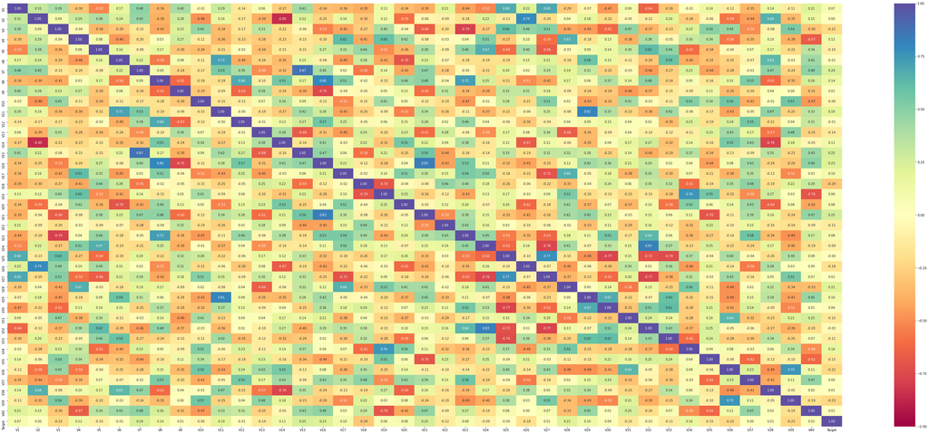

```python
# Attempt to see on heatmap
plt.figure(figsize=(60, 25))
sns.heatmap(bc.corr(), annot=True, vmin=-1, vmax=1, fmt=".2f", cmap="Spectral")
plt.show()
```

#### Observations

1. There are lots of strong correlation between the 40 predictors but none will be dropped due to the nature of the problem
2. Heatmap is not visual

```python
# Creating barplots that indicate percentage for each category.
# Please note that this is referenced from mentor learning session
def bar_perc(plot, feature):
    '''
    plot
    feature: 1-d categorical feature array
    '''
    total = len(feature) # length of the column
    for p in ax.patches:
        percentage = '{:.1f}%'.format(100 * p.get_height()/total) # percentage of each class of the category
        x = p.get_x() + p.get_width() / 2 - 0.05 # width of the plot
        y = p.get_y() + p.get_height()           # height of the plot
        ax.annotate(percentage, (x, y), size = 12) # annotate the percentage
```

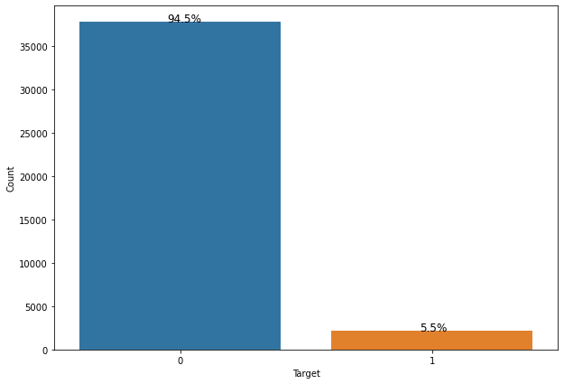

```python
# Plot % Count for Target
plt.figure(figsize=(10,7))
ax = sns.countplot(bc['Target'])
plt.xlabel('Target')
plt.ylabel('Count')

bar_perc(ax, bc['Target'])
```

#### Observations

Only 5.5% of the observation provided has minimum possible maintenance cost

# Data Pre-Processing

## Missing Value Treatment

```python
# checking for missing values
bc.isnull().sum()
```

```
V1        46
V2        39
V3         0
V4         0
V5         0
V6         0
V7         0
V8         0
V9         0
V10        0
V11        0
V12        0
V13        0
V14        0
V15        0
V16        0
V17        0
V18        0
V19        0
V20        0
V21        0
V22        0
V23        0
V24        0
V25        0
V26        0
V27        0
V28        0
V29        0
V30        0
V31        0
V32        0
V33        0
V34        0
V35        0
V36        0
V37        0
V38        0
V39        0
V40        0
Target     0
dtype: int64
```

#### Observations

Two of the variables have rows with missing values  
We will treat them

```python
# Replace missing values with median
bc=bc.fillna(bc.median())
```

```python
#Check the new data
bc.info()
```

```
<class 'pandas.core.frame.DataFrame'>
RangeIndex: 40000 entries, 0 to 39999
Data columns (total 41 columns):
 #   Column  Non-Null Count  Dtype
---  ------  --------------  -----
 0   V1      40000 non-null  float64
 1   V2      40000 non-null  float64
 2   V3      40000 non-null  float64
 3   V4      40000 non-null  float64
 4   V5      40000 non-null  float64
 5   V6      40000 non-null  float64
 6   V7      40000 non-null  float64
 7   V8      40000 non-null  float64
 8   V9      40000 non-null  float64
 9   V10     40000 non-null  float64
```

[output cut: 33 more lines]

```python
# checking for missing values
book_Test.isnull().sum()
```

```
V1        11
V2         7
V3         0
V4         0
V5         0
V6         0
V7         0
V8         0
V9         0
V10        0
V11        0
V12        0
V13        0
V14        0
V15        0
V16        0
V17        0
V18        0
V19        0
V20        0
V21        0
V22        0
V23        0
V24        0
V25        0
V26        0
V27        0
V28        0
V29        0
V30        0
V31        0
V32        0
V33        0
V34        0
V35        0
V36        0
V37        0
V38        0
V39        0
V40        0
Target     0
dtype: int64
```

```python
# Replace missing values with median
book_Test=book_Test.fillna(book_Test.median())
```

## Model evaluation criterion

### 3 types of cost are associated with the provided problem

1. Replacement cost - False Negatives - Predicting no failure, while there will be a failure
2. Inspection cost - False Positives - Predicting failure, while there is no failure
3. Repair cost - True Positives - Predicting failure correctly

### How to reduce the overall cost?

- We need to create a customized metric, that can help to bring down the overall cost.
- The cost associated with any model = TP *15000 + FP* 5000 + FN * 40000
- And the minimum possible cost will be when, the model will be able to identify all failures, in that case, the cost will be (TP + FN) * 15000
- So, we will try to maximize `Minimum cost/Cost associated with model`

```python
# defining a function to compute different metrics to check performance of a classification model built using sklearn
def model_performance_classification_sklearn(model, predictors, target):
    """
    Function to compute different metrics to check classification model performance

    model: classifier
    predictors: independent variables
    target: dependent variable
    """

    TP = confusion_matrix(target, model.predict(predictors))[1, 1]
    FP = confusion_matrix(target, model.predict(predictors))[0, 1]
    FN = confusion_matrix(target, model.predict(predictors))[1, 0]
    Cost = TP * 15 + FP * 5 + FN * 40  # maintenance cost by using model
    Min_Cost = (TP + FN) * 15  # minimum possible maintenance cost = number of actual positives
    Percent = Min_Cost / Cost  # ratio of minimum possible maintenance cost and maintenance cost by model

    # predicting using the independent variables
    pred = model.predict(predictors)

    acc = accuracy_score(target, pred)  # to compute Accuracy
    recall = recall_score(target, pred)  # to compute Recall
    precision = precision_score(target, pred)  # to compute Precision
    f1 = f1_score(target, pred)  # to compute F1-score

    # creating a dataframe of metrics
    df_perf = pd.DataFrame(
        {
            "Accuracy": acc,
            "Recall": recall,
            "Precision": precision,
            "F1": f1,
            "Minimum_Vs_Model_cost": Percent,
        },
        index=[0],
    )

    return df_perf
```

```python
def confusion_matrix_sklearn(model, predictors, target):
    """
    To plot the confusion_matrix with percentages

    model: classifier
    predictors: independent variables
    target: dependent variable
    """
    y_pred = model.predict(predictors)
    cm = confusion_matrix(target, y_pred)
    labels = np.asarray(
        [
            ["{0:0.0f}".format(item) + "\n{0:.2%}".format(item / cm.flatten().sum())]
            for item in cm.flatten()
        ]
    ).reshape(2, 2)

    plt.figure(figsize=(6, 4))
    sns.heatmap(cm, annot=labels, fmt="")
    plt.ylabel("True label")
    plt.xlabel("Predicted label")
```

## **Defining scorer to be used for hyperparameter tuning**

- Every prediction of a classification model will be either a TP, FP, FN or TN.
- Till now at most of the places we wanted to reduce False negatives and hence we tried to maximize "Recall".
- To maximize Recall, we used Recall as a **scorer** in hyperparameter tuning.
- Here, we not only want to minimize false negatives but also false positives and we are also given the costs associated with each type of prediction.
- So, overall we want to reduce the maintenance cost which is: `TP*(Repair cost) + FN*(Replacement cost) + FP*(Inspection cost)`
- In simple language, we can say that we are assigning different weightage to the different types of predictions.
- Do we have any such metric which can help us minimize the maintenance cost? i.e., help us reduce FP and FN as per the weightage - We don't have any such inbuilt metric.
- In sklearn, we can define **custom scorers** also as per our need.
- For this classification problem, we need to reduce the maintenance cost, which can be reiterated as:
  - Minimize (maintenance cost)
  - Maximize (1/maintenance cost)
  - Maximize (minimum possible maintenance cost/maintenance cost)
- Eventually, all 3 metrics will do the same work in the backend and the only difference will be in the scale of the values of the metric.
- The metric provided in the next cell is to `maximize(minimum possible maintenance cost/maintenance cost)`
- You can modify the metric as per convenience and use it further to tune the models.

```python
# defining metric to be used for optimization and with cross-validation
def Minimum_Vs_Model_cost(y_train, y_pred):
    """
    We want the model to optimize the maintenance cost and reduce it to the lowest possible value.
    The lowest possible maintenance cost will be achieved when each sample is predicted correctly.

    In such a scenario, the maintenance cost will be the total number of failures times the maintenance cost of replacing one generator,
    which is given by (TP + FN) * 40 (i.e., the actual positives*40).
    For any other scenario,
    the maintenance cost associated with the model will be given by (TP * 15 + FP * 5 + FN * 40).

    We will use the ratio of these two maintenance costs as the cost function for our model.
    The greater the ratio, the lower the associated maintenance cost and the better the model.
    """
    TP = confusion_matrix(y_train, y_pred)[1, 1]
    FP = confusion_matrix(y_train, y_pred)[0, 1]
    FN = confusion_matrix(y_train, y_pred)[1, 0]
    return ((TP + FN) * 15) / (TP * 15 + FP * 5 + FN * 40)


# A value of .80 here, will represent that the minimum maintenance cost is 80% of the maintenance cost associated with the model.
# Since minimum maintenance cost is constant for any data, when minimum cost will become 100% of maintenance cost associated with the model
# Model will have give the least possible maintenance cost.


# Type of scoring used to compare parameter combinations
scorer = metrics.make_scorer(Minimum_Vs_Model_cost, greater_is_better=True)

# Higher the values, the lower the maintenance cost
```

```python
# defining x and y variables
X = bc.drop(["Target"], axis=1)
y = bc["Target"]

print(X.head())
print(y.head())
```

```
         V1        V2        V3        V4        V5        V6        V7  \
0 -4.464606 -4.679129  3.101546  0.506130 -0.221083 -2.032511 -2.910870
1 -2.909996 -2.568662  4.109032  1.316672 -1.620594 -3.827212 -1.616970
2  4.283674  5.105381  6.092238  2.639922 -1.041357  1.308419 -1.876140
3  3.365912  3.653381  0.909671 -1.367528  0.332016  2.358938  0.732600
4 -3.831843 -5.824444  0.634031 -2.418815 -1.773827  1.016824 -2.098941

         V8        V9       V10       V11       V12       V13       V14  \
0  0.050714 -1.522351  3.761892 -5.714719  0.735893  0.981251  1.417884
1  0.669006  0.387045  0.853814 -6.352826  4.271718  3.162020  0.257559
2 -9.582412  3.469504  0.763395 -2.573231 -3.349664 -0.594666 -5.246841
3 -4.332135  0.565695 -0.101080  1.914465 -0.951458 -1.255259 -2.706522
4 -3.173204 -2.081860  5.392621 -0.770673  1.106718  1.144261  0.943301

        V15        V16       V17       V18       V19       V20        V21  \
```

[output cut: 32 more lines]

```python
# Splitting data into training and validation set:

X_train, X_val, y_train, y_val = train_test_split(
    X, y, test_size=0.3, random_state=1, stratify=y
)
print(X_train.shape, X_val.shape)
```

```
(28000, 40) (12000, 40)
```

## Model Building with Original Data

```python
models = []  # Empty list to store all the models

# Appending models into the list
models.append(("Bagging", BaggingClassifier(random_state=1)))
models.append(("Random forest", RandomForestClassifier(random_state=1)))
models.append(("GBM", GradientBoostingClassifier(random_state=1)))
models.append(("Adaboost", AdaBoostClassifier(random_state=1)))
models.append(("Xgboost", XGBClassifier(random_state=1, eval_metric="logloss")))
models.append(("dtree", DecisionTreeClassifier(random_state=1)))
models.append(("log_reg", LogisticRegression(random_state=1)))

results = []  # Empty list to store all model's CV scores
names = []  # Empty list to store name of the models


# loop through all models to get the mean cross validated score
print("\n" "Cross-Validation Performance:" "\n")

for name, model in models:
    scoring = scorer
    kfold = StratifiedKFold(
        n_splits=5, shuffle=True, random_state=1
    )  # Setting number of splits equal to 5
    cv_result = cross_val_score(
        estimator=model, X=X_train, y=y_train, scoring=scoring, cv=kfold
    )
    results.append(cv_result)
    names.append(name)
    print("{}: {}".format(name, cv_result.mean() * 100))

print("\n" "Training Performance:" "\n")

for name, model in models:
    model.fit(X_train, y_train)
    scores = Minimum_Vs_Model_cost(y_train, model.predict(X_train)) * 100
    print("{}: {}".format(name, scores))
```

```
Cross-Validation Performance:

Bagging: 68.12807591389468
Random forest: 71.09742970474746
GBM: 67.82623334842278
Adaboost: 60.233603154203706
Xgboost: 77.13551730843292
dtree: 65.60666496504416
log_reg: 53.15403616048175

Training Performance:

Bagging: 93.39162261081741
Random forest: 99.89125706829056
GBM: 73.10202132739137
Adaboost: 60.778086542278686
Xgboost: 100.0
dtree: 100.0
log_reg: 53.196664350243225
```

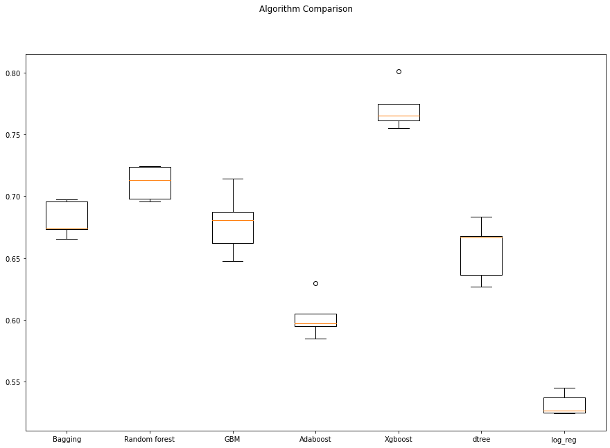

```python
# Plotting boxplots for CV scores of all models defined above
fig = plt.figure(figsize=(15, 10))

fig.suptitle("Algorithm Comparison")
ax = fig.add_subplot(111)

plt.boxplot(results)
ax.set_xticklabels(names)

plt.show()
```

## Building Model with Oversampled Data

```python
# Synthetic Minority Over Sampling Technique
sm = SMOTE(sampling_strategy=1, k_neighbors=5, random_state=1)
X_train_over, y_train_over = sm.fit_resample(X_train, y_train)
```

```python
models = []  # Empty list to store all the models

# Appending models into the list
models.append(("Bagging_over", BaggingClassifier(random_state=1)))
models.append(("Random forest_over", RandomForestClassifier(random_state=1)))
models.append(("GBM_over", GradientBoostingClassifier(random_state=1)))
models.append(("Adaboost_over", AdaBoostClassifier(random_state=1)))
models.append(("Xgboost_over", XGBClassifier(random_state=1, eval_metric="logloss")))
models.append(("dtree_over", DecisionTreeClassifier(random_state=1)))
models.append(("log_reg_over", LogisticRegression(random_state=1)))

results_over = []  # Empty list to store all model's CV scores
names_over = []  # Empty list to store name of the models


# loop through all models to get the mean cross validated score
print("\n" "Cross-Validation Performance:" "\n")

for name, model in models:
    scoring = scorer
    kfold = StratifiedKFold(
        n_splits=5, shuffle=True, random_state=1
    )  # Setting number of splits equal to 5
    cv_result = cross_val_score(
        estimator=model, X=X_train_over, y=y_train_over, scoring=scoring, cv=kfold
    )
    results_over.append(cv_result)
    names_over.append(name)
    print("{}: {}".format(name, cv_result.mean() * 100))

print("\n" "Training Performance:" "\n")

for name, model in models:
    model.fit(X_train_over, y_train_over)
    scores = Minimum_Vs_Model_cost(y_train_over, model.predict(X_train_over)) * 100
    print("{}: {}".format(name, scores))
```

```
Cross-Validation Performance:

Bagging_over: 95.67710595379042
Random forest_over: 96.84569635390494
GBM_over: 86.98213334032019
Adaboost_over: 83.02735716914681
Xgboost_over: 97.35494688964317
dtree_over: 93.5799411923789
log_reg_over: 79.91885856657728

Training Performance:

Bagging_over: 99.76255088195387
Random forest_over: 100.0
GBM_over: 87.26427535276275
Adaboost_over: 83.45542254779346
Xgboost_over: 99.79264062735635
dtree_over: 100.0
log_reg_over: 79.97723770483547
```

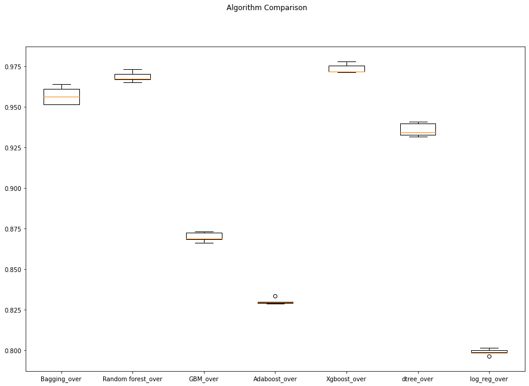

```python
# Plotting boxplots for CV scores of all models defined above
fig = plt.figure(figsize=(15, 10))

fig.suptitle("Algorithm Comparison")
ax = fig.add_subplot(111)

plt.boxplot(results_over)
ax.set_xticklabels(names_over)

plt.show()
```

## Model Building with Undersampled data

```python
# Random undersampler for under sampling the data
rus = RandomUnderSampler(random_state=1, sampling_strategy=1)
X_train_un, y_train_un = rus.fit_resample(X_train, y_train)
```

```python
models = []  # Empty list to store all the models

# Appending models into the list
models.append(("Bagging_under", BaggingClassifier(random_state=1)))
models.append(("Random forest_under", RandomForestClassifier(random_state=1)))
models.append(("GBM_under", GradientBoostingClassifier(random_state=1)))
models.append(("Adaboost_under", AdaBoostClassifier(random_state=1)))
models.append(("Xgboost_under", XGBClassifier(random_state=1, eval_metric="logloss")))
models.append(("dtree_under", DecisionTreeClassifier(random_state=1)))
models.append(("log_reg_under", LogisticRegression(random_state=1)))

results_un = []  # Empty list to store all model's CV scores
names_un = []  # Empty list to store name of the models


# loop through all models to get the mean cross validated score
print("\n" "Cross-Validation Performance:" "\n")

for name, model in models:
    scoring = scorer
    kfold = StratifiedKFold(
        n_splits=5, shuffle=True, random_state=1
    )  # Setting number of splits equal to 5
    cv_result = cross_val_score(
        estimator=model, X=X_train_un, y=y_train_un, scoring=scoring, cv=kfold
    )
    results_un.append(cv_result)
    names_un.append(name)
    print("{}: {}".format(name, cv_result.mean() * 100))

print("\n" "Training Performance:" "\n")

for name, model in models:
    model.fit(X_train_un, y_train_un)
    scores = Minimum_Vs_Model_cost(y_train_un, model.predict(X_train_un)) * 100
    print("{}: {}".format(name, scores))
```

```
Cross-Validation Performance:

Bagging_under: 81.0537034879969
Random forest_under: 84.2602547619812
GBM_under: 82.60845219126203
Adaboost_under: 78.75970384722429
Xgboost_under: 84.05650028470488
dtree_under: 76.23582706765808
log_reg_under: 77.24863000214184

Training Performance:

Bagging_under: 96.24895222129086
Random forest_under: 100.0
GBM_under: 87.26961808854266
Adaboost_under: 81.97394253078708
Xgboost_under: 100.0
dtree_under: 100.0
log_reg_under: 77.23221792500419
```

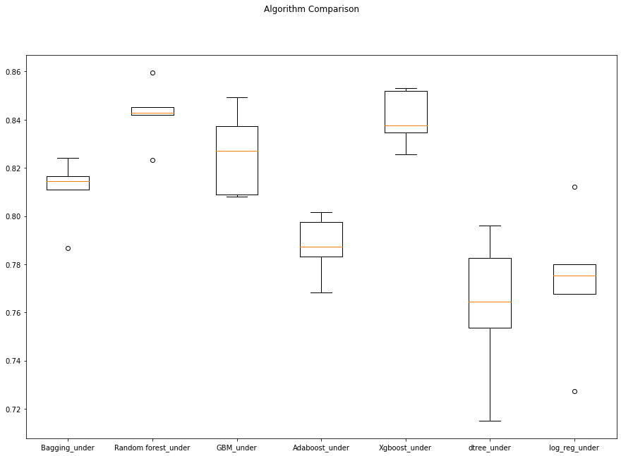

```python
# Plotting boxplots for CV scores of all models defined above
fig = plt.figure(figsize=(15, 10))

fig.suptitle("Algorithm Comparison")
ax = fig.add_subplot(111)

plt.boxplot(results_un)
ax.set_xticklabels(names_un)

plt.show()
```

## Model Selection

```python
#Combine all model results
results_all = []  # Empty list to store all model's CV scores
names_all = []  # Empty list to store name of the models

for result in results:
    results_all.append(result)
for result in results_over:
    results_all.append(result)
for result in results_un:
    results_all.append(result)
for result in names:
    names_all.append(result)
for result in names_over:
    names_all.append(result)
for result in names_un:
    names_all.append(result)
```

```python
results_all
```

```
[array([0.66569978, 0.6959818 , 0.67351431, 0.67400881, 0.69719909]),
 array([0.71328671, 0.72397476, 0.69809886, 0.69545455, 0.7240566 ]),
 array([0.68050408, 0.68712575, 0.66233766, 0.64739069, 0.71395349]),
 array([0.62962963, 0.59494491, 0.58471338, 0.5972674 , 0.60512484]),
 array([0.76119403, 0.80104712, 0.75493421, 0.765     , 0.7746005 ]),
 array([0.66763636, 0.66666667, 0.63617464, 0.62662116, 0.68323442]),
 array([0.54480712, 0.53715623, 0.52487136, 0.52667814, 0.52418896]),
 array([0.95141676, 0.96377207, 0.95628613, 0.96084957, 0.95153077]),
 array([0.96717618, 0.97298291, 0.96694064, 0.97012463, 0.96506046]),
 array([0.86621216, 0.87321311, 0.86834336, 0.87242459, 0.86891345]),
 array([0.82921735, 0.82895767, 0.82986728, 0.83371837, 0.82960719]),
 array([0.97173275, 0.97519342, 0.97167329, 0.97783115, 0.97131674]),
 array([0.9341254 , 0.93970771, 0.94059816, 0.9328516 , 0.93171419]),
 array([0.79905414, 0.80175678, 0.79640959, 0.79870228, 0.80002015]),
 array([0.81455191, 0.81648936, 0.78663239, 0.81095406, 0.82405745]),
 array([0.84530387, 0.84186472, 0.84297521, 0.82331839, 0.85955056]),
 array([0.82702703, 0.83727273, 0.80809859, 0.80881057, 0.84921369]),
 array([0.80174672, 0.78316327, 0.76820084, 0.78730703, 0.79756733]),
 array([0.83759124, 0.8519889 , 0.83454545, 0.82553957, 0.85315985]),
 array([0.79618387, 0.75368249, 0.71495327, 0.76436303, 0.7826087 ]),
 array([0.76755853, 0.81216931, 0.7274168 , 0.77533784, 0.77994902])]
```

#### Observations

1. OverSampling Models have the highest Cross-validation scores followed by UnderSampling Models
2. Models for HyperparameterTuning are: OverSampled Data of Xgboost, RandomForest, Bagging and DecisionTree because they have highest Cross-validation scores and there is no major difference in the training scores and the cross validation scores
3. XGBoost will not be run due to the time constraints involved

## Hyperparemeter Tuning

- **Hyperparameter tuning can take a long time to run, so to avoid that time complexity - you can use the following grids, wherever required.**

#### For XGBoost:

param_grid={'n_estimators':np.arange(150,300,50),'scale_pos_weight':[5,10], 'learning_rate':[0.1,0.2], 'gamma':[0,3,5], 'subsample':[0.8,0.9]}

#### For Gradient Boosting:

param_grid = { "init": [AdaBoostClassifier(random_state=1),DecisionTreeClassifier(random_state=1)], "n_estimators": np.arange(75,150,25), "learning_rate": [0.2, 0.05, 1], "subsample":[0.5,0.7], "max_features":[0.5,0.7]}

#### For Adaboost:

param_grid = { "n_estimators": np.arange(10, 110, 20), "learning_rate": [ 0.2, 0.05, 1], "base_estimator": [ DecisionTreeClassifier(max_depth=1, random_state=1), DecisionTreeClassifier(max_depth=2, random_state=1), DecisionTreeClassifier(max_depth=3, random_state=1)]}

#### For logistic Regression:

param_grid = {'C': np.arange(0.1,1.1,0.1)}

#### For Bagging Classifier:

param_grid = { 'max_samples': [0.8,0.9], 'max_features': [0.8,0.9], 'n_estimators' : [40,50]}

#### For Random Forest:

param_grid = { "n_estimators": [150,250], "min_samples_leaf": np.arange(1, 3), "max_features": ['sqrt','log2'], "max_samples": np.arange(0.2, 0.6, 0.1)}

#### For Decision Trees:

param_grid = {'max_depth': np.arange(2,20), 'min_samples_leaf': [1, 2, 5, 7], 'max_leaf_nodes' : [5, 10,15], 'min_impurity_decrease': [0.0001,0.001] }

## Oversampled Random Forest Classifier

#### GridSearchCV

```python
%%time

# defining model
model = RandomForestClassifier(random_state=1)

# Parameter grid to pass in GridSearchCV
param_grid = { "n_estimators": [150,250], "min_samples_leaf": np.arange(1, 3),
              "max_features": ['sqrt','log2'], "max_samples": np.arange(0.2, 0.6, 0.1)}
# Type of scoring used to compare parameter combinations
scorer = metrics.make_scorer(metrics.recall_score)
#scorer = metrics.make_scorer(Minimum_Vs_Model_cost, greater_is_better=True)

#Calling GridSearchCV
grid_cv_rf = GridSearchCV(estimator=model, param_grid=param_grid, scoring=scorer, cv=5, n_jobs = -1)

# Fitting parameters in GridSearchCV
grid_cv_rf.fit(X_train_over, y_train_over)

print(
    "Best Parameters:{} \nScore: {}".format(grid_cv_rf.best_params_, grid_cv_rf.best_score_)
)
```

```
Best Parameters:{'max_features': 'log2', 'max_samples': 0.5000000000000001, 'min_samples_leaf': 1, 'n_estimators': 250}
Score: 0.9752163705533488
Wall time: 34min 7s
```

```python
# building model with best parameters
randfr_tuned1 = RandomForestClassifier(
    n_estimators=250,
    max_features='log2',
    max_samples=0.5000000000000001,
    min_samples_leaf=1)

# Fit the model on training data
randfr_tuned1.fit(X_train_over, y_train_over)
```

```
RandomForestClassifier(max_features='log2', max_samples=0.5000000000000001,
                       n_estimators=250)
```

```python
# Calculating different metrics on train set
RandomForest_grid_train = model_performance_classification_sklearn(
    randfr_tuned1, X_train_over, y_train_over
)
print("Training performance:")
RandomForest_grid_train
```

```
Training performance:
```

|  | Accuracy | Recall | Precision | F1 | Minimum_Vs_Model_cost |
| --- | --- | --- | --- | --- | --- |
| 0 | 0.998904 | 0.998073 | 0.999735 | 0.998903 | 0.996711 |

```python
# Calculating different metrics on validation set
RandomForest_grid_val = model_performance_classification_sklearn(randfr_tuned1, X_val, y_val)
print("Validation performance:")
RandomForest_grid_val
```

```
Validation performance:
```

|  | Accuracy | Recall | Precision | F1 | Minimum_Vs_Model_cost |
| --- | --- | --- | --- | --- | --- |
| 0 | 0.989583 | 0.868902 | 0.935961 | 0.901186 | 0.80755 |

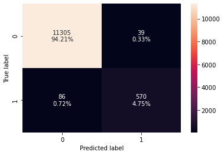

```python
# creating confusion matrix
confusion_matrix_sklearn(randfr_tuned1, X_val, y_val)
```

### RandomizedSearchCV

```python
%%time

# defining model
model = RandomForestClassifier(random_state=1)

# Parameter grid to pass in GridSearchCV
param_grid = { "n_estimators": [150,250], "min_samples_leaf": np.arange(1, 3),
              "max_features": ['sqrt','log2'], "max_samples": np.arange(0.2, 0.6, 0.1)}
# Type of scoring used to compare parameter combinations
scorer = metrics.make_scorer(metrics.recall_score)
#scorer = metrics.make_scorer(Minimum_Vs_Model_cost, greater_is_better=True)

#Calling GridSearchCV
random_cv_rf = RandomizedSearchCV(estimator=model, param_distributions=param_grid, n_iter=50, scoring=scorer, cv=5, n_jobs = -1)

# Fitting parameters in GridSearchCV
random_cv_rf.fit(X_train_over, y_train_over)

print(
    "Best Parameters:{} \nScore: {}".format(random_cv_rf.best_params_, random_cv_rf.best_score_)
)
```

```
Best Parameters:{'n_estimators': 250, 'min_samples_leaf': 1, 'max_samples': 0.5000000000000001, 'max_features': 'log2'}
Score: 0.9752163705533488
Wall time: 22min 35s
```

```python
# building model with best parameters
randfr_tuned2 = RandomForestClassifier(
    n_estimators=250,
    max_features='log2',
    max_samples=0.5000000000000001,
    min_samples_leaf=1)

# Fit the model on training data
randfr_tuned2.fit(X_train_over, y_train_over)
```

```
RandomForestClassifier(max_features='log2', max_samples=0.5000000000000001,
                       n_estimators=250)
```

```python
# Calculating different metrics on train set
RandomForest_ran_train = model_performance_classification_sklearn(
    randfr_tuned2, X_train_over, y_train_over
)
print("Training performance:")
RandomForest_ran_train
```

```
Training performance:
```

|  | Accuracy | Recall | Precision | F1 | Minimum_Vs_Model_cost |
| --- | --- | --- | --- | --- | --- |
| 0 | 0.999093 | 0.998564 | 0.999622 | 0.999093 | 0.997488 |

```python
# Calculating different metrics on train set
RandomForest_ran_val = model_performance_classification_sklearn(
    randfr_tuned2, X_val, y_val
)
print("Validation performance:")
RandomForest_ran_val
```

```
Validation performance:
```

|  | Accuracy | Recall | Precision | F1 | Minimum_Vs_Model_cost |
| --- | --- | --- | --- | --- | --- |
| 0 | 0.99025 | 0.871951 | 0.945455 | 0.907216 | 0.812887 |

[figure not shown]

```python
# creating confusion matrix
confusion_matrix_sklearn(randfr_tuned2, X_val, y_val)
```

## Decision Tree Classifiers

### GridSearch CV

```python
%%time

# defining model
model = DecisionTreeClassifier(random_state=1)

# Parameter grid to pass in GridSearchCV

param_grid = {'max_depth': np.arange(2,20), 'min_samples_leaf': [1, 2, 5, 7], 'max_leaf_nodes' : [5, 10,15], 'min_impurity_decrease': [0.0001,0.001] }

# Type of scoring used to compare parameter combinations
scorer = metrics.make_scorer(metrics.recall_score)
#scorer = metrics.make_scorer(Minimum_Vs_Model_cost, greater_is_better=True)

# Calling GridSearchCV
grid_cv = GridSearchCV(estimator=model, param_grid=param_grid, scoring=scorer, cv=5, n_jobs = -1)

# Fitting parameters in GridSearchCV
grid_cv.fit(X_train_over, y_train_over)

print(
    "Best Parameters:{} \nScore: {}".format(grid_cv.best_params_, grid_cv.best_score_)
)
```

```
Best Parameters:{'max_depth': 6, 'max_leaf_nodes': 15, 'min_impurity_decrease': 0.0001, 'min_samples_leaf': 1}
Score: 0.8659937343024777
Wall time: 12min 36s
```

```python
# building model with best parameters
dectree_tuned1 = DecisionTreeClassifier(
    max_depth= 6,
    max_leaf_nodes= 15,
    min_impurity_decrease= 0.0001,
    min_samples_leaf= 1)

# Fit the model on training data
dectree_tuned1.fit(X_train_over, y_train_over)
```

```
DecisionTreeClassifier(max_depth=6, max_leaf_nodes=15,
                       min_impurity_decrease=0.0001)
```

```python
# Calculating different metrics on train set
DecTree_grid_train = model_performance_classification_sklearn(
   dectree_tuned1, X_train_over, y_train_over
)
print("Training performance:")
DecTree_grid_train
```

```
Training performance:
```

|  | Accuracy | Recall | Precision | F1 | Minimum_Vs_Model_cost |
| --- | --- | --- | --- | --- | --- |
| 0 | 0.893951 | 0.854207 | 0.92797 | 0.889562 | 0.790458 |

```python
# Calculating different metrics on validation set
DecTree_grid_val = model_performance_classification_sklearn(
     dectree_tuned1, X_val, y_val
)
print("Validation performance:")
DecTree_grid_val
```

```
Validation performance:
```

|  | Accuracy | Recall | Precision | F1 | Minimum_Vs_Model_cost |
| --- | --- | --- | --- | --- | --- |
| 0 | 0.923917 | 0.8125 | 0.402872 | 0.538656 | 0.583457 |

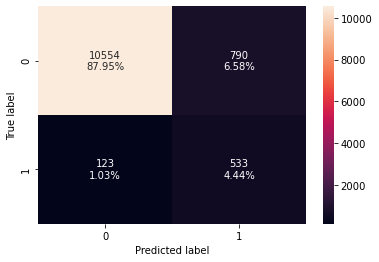

```python
# creating confusion matrix
confusion_matrix_sklearn(dectree_tuned1, X_val, y_val)
```

### RandomSearchCV

```python
%%time

# defining model
model = DecisionTreeClassifier(random_state=1)

# Parameter grid to pass in GridSearchCV

param_grid = {'max_depth': np.arange(2,20), 'min_samples_leaf': [1, 2, 5, 7], 'max_leaf_nodes' : [5, 10,15], 'min_impurity_decrease': [0.0001,0.001] }

# Type of scoring used to compare parameter combinations
scorer = metrics.make_scorer(metrics.recall_score)
#scorer = metrics.make_scorer(Minimum_Vs_Model_cost, greater_is_better=True)

#Calling RandomizedSearchCV
randomized_cv = RandomizedSearchCV(estimator=model, param_distributions=param_grid, n_jobs = -1, n_iter=50, scoring=scorer, cv=5, random_state=1)

#Fitting parameters in RandomizedSearchCV
randomized_cv.fit(X_train_over,y_train_over)

print("Best parameters are {} with CV score={}:" .format(randomized_cv.best_params_,randomized_cv.best_score_))
```

```
Best parameters are {'min_samples_leaf': 7, 'min_impurity_decrease': 0.001, 'max_leaf_nodes': 15, 'max_depth': 6} with CV score=0.8659937343024777:
Wall time: 1min 22s
```

```python
# building model with best parameters
dectree_tuned2 = DecisionTreeClassifier(
    max_depth= 6,
    max_leaf_nodes= 15,
    min_impurity_decrease= 0.001,
    min_samples_leaf= 7)

# Fit the model on training data
dectree_tuned2.fit(X_train_over, y_train_over)
```

```
DecisionTreeClassifier(max_depth=6, max_leaf_nodes=15,
                       min_impurity_decrease=0.001, min_samples_leaf=7)
```

```python
# Calculating different metrics on train set
DecTree_ran_train = model_performance_classification_sklearn(
    dectree_tuned2, X_train_over, y_train_over
)
print("Training performance:")
DecTree_ran_train
```

```
Training performance:
```

|  | Accuracy | Recall | Precision | F1 | Minimum_Vs_Model_cost |
| --- | --- | --- | --- | --- | --- |
| 0 | 0.893951 | 0.854207 | 0.92797 | 0.889562 | 0.790458 |

```python
# Calculating different metrics on validation set
DecTree_ran_val = model_performance_classification_sklearn(
     dectree_tuned2, X_val, y_val
)
print("Validation performance:")
DecTree_ran_val
```

```
Validation performance:
```

|  | Accuracy | Recall | Precision | F1 | Minimum_Vs_Model_cost |
| --- | --- | --- | --- | --- | --- |
| 0 | 0.923917 | 0.8125 | 0.402872 | 0.538656 | 0.583457 |

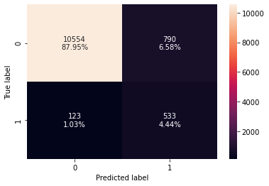

```python
# creating confusion matrix
confusion_matrix_sklearn(dectree_tuned2, X_val, y_val)
```

### Bagging Classifier Over Sampling

### GridSearch CV

```python
%%time

# defining model
model = BaggingClassifier(random_state=1)

# Parameter grid to pass in GridSearchCV

param_grid = { 'max_samples': [0.8,0.9], 'max_features': [0.8,0.9], 'n_estimators' : [40,50]}

# Type of scoring used to compare parameter combinations
scorer = metrics.make_scorer(metrics.recall_score)
#scorer = metrics.make_scorer(Minimum_Vs_Model_cost, greater_is_better=True)

# Calling GridSearchCV
grid_cv = GridSearchCV(estimator=model, param_grid=param_grid, scoring=scorer, cv=5, n_jobs = -1)

# Fitting parameters in GridSearchCV
grid_cv.fit(X_train_over, y_train_over)

print(
    "Best Parameters:{} \nScore: {}".format(grid_cv.best_params_, grid_cv.best_score_)
)
```

```
Best Parameters:{'max_features': 0.8, 'max_samples': 0.9, 'n_estimators': 50}
Score: 0.9794854256832217
Wall time: 17min 53s
```

```python
# building model with best parameters
bagging_tuned1 = BaggingClassifier(
    max_features= 0.8,
   n_estimators= 50,
    max_samples= 0.9)

# Fit the model on training data
bagging_tuned1.fit(X_train_over, y_train_over)
```

```
BaggingClassifier(max_features=0.8, max_samples=0.9, n_estimators=50)
```

```python
# Calculating different metrics on train set
Bagging_grid_train = model_performance_classification_sklearn(
    bagging_tuned1, X_train_over, y_train_over
)
print("Training performance:")
Bagging_grid_train
```

```
Training performance:
```

|  | Accuracy | Recall | Precision | F1 | Minimum_Vs_Model_cost |
| --- | --- | --- | --- | --- | --- |
| 0 | 0.999943 | 0.999924 | 0.999962 | 0.999943 | 0.999861 |

```python
# Calculating different metrics on validation set
Bagging_grid_val = model_performance_classification_sklearn(
     bagging_tuned1, X_val, y_val
)
print("Validation performance:")
Bagging_grid_val
```

```
Validation performance:
```

|  | Accuracy | Recall | Precision | F1 | Minimum_Vs_Model_cost |
| --- | --- | --- | --- | --- | --- |
| 0 | 0.988583 | 0.856707 | 0.928926 | 0.891356 | 0.793229 |

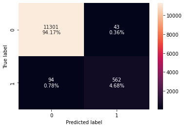

```python
# creating confusion matrix
confusion_matrix_sklearn(bagging_tuned1, X_val, y_val)
```

### RandomSearch CV

```python
%%time

# defining model
model = BaggingClassifier(random_state=1)

# Parameter grid to pass in GridSearchCV

param_grid = { 'max_samples': [0.8,0.9], 'max_features': [0.8,0.9], 'n_estimators' : [40,50]}

# Type of scoring used to compare parameter combinations
scorer = metrics.make_scorer(metrics.recall_score)
#scorer = metrics.make_scorer(Minimum_Vs_Model_cost, greater_is_better=True)

#Calling RandomizedSearchCV
randomized_cv = RandomizedSearchCV(estimator=model, param_distributions=param_grid, n_jobs = -1, n_iter=50, scoring=scorer, cv=5, random_state=1)

#Fitting parameters in RandomizedSearchCV
randomized_cv.fit(X_train_over,y_train_over)

print("Best parameters are {} with CV score={}:" .format(randomized_cv.best_params_,randomized_cv.best_score_))
```

```
Best parameters are {'n_estimators': 50, 'max_samples': 0.9, 'max_features': 0.8} with CV score=0.9794854256832217:
Wall time: 17min 56s
```

```python
# building model with best parameters
bagging_tuned2 = BaggingClassifier(
    max_features= 0.8,
   n_estimators= 50,
    max_samples= 0.9)

# Fit the model on training data
bagging_tuned2.fit(X_train_over, y_train_over)
```

```
BaggingClassifier(max_features=0.8, max_samples=0.9, n_estimators=50)
```

```python
# Calculating different metrics on train set
Bagging_ran_train = model_performance_classification_sklearn(
    bagging_tuned2, X_train_over, y_train_over
)
print("Training performance:")
Bagging_ran_train
```

```
Training performance:
```

|  | Accuracy | Recall | Precision | F1 | Minimum_Vs_Model_cost |
| --- | --- | --- | --- | --- | --- |
| 0 | 0.999943 | 0.999962 | 0.999924 | 0.999943 | 0.999912 |

```python
# Calculating different metrics on validation set
Bagging_ran_val = model_performance_classification_sklearn(
     bagging_tuned2, X_val, y_val
)
print("Validation performance:")
Bagging_ran_val
```

```
Validation performance:
```

|  | Accuracy | Recall | Precision | F1 | Minimum_Vs_Model_cost |
| --- | --- | --- | --- | --- | --- |
| 0 | 0.988333 | 0.86128 | 0.920195 | 0.889764 | 0.796117 |

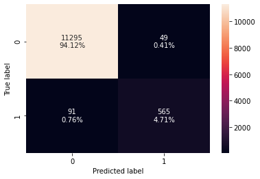

```python
# creating confusion matrix
confusion_matrix_sklearn(bagging_tuned2, X_val, y_val)
```

## Model Comparison

```python
# training performance comparison

models_train_comp_df = pd.concat(
    [
        RandomForest_grid_train.T,
        RandomForest_ran_train.T,
        DecTree_grid_train.T,
        DecTree_ran_train.T,
        Bagging_grid_train.T,
        Bagging_ran_train.T
    ],
    axis=1,
)
models_train_comp_df.columns = [
    "RandomForest Tuned with Grid search",
    "RandomForest Tuned with Random search",
    "DecisionTree Tuned with Grid search",
    "DecisionTree Tuned with Random Search",
    "Bagging Tuned with Grid search",
    "Bagging Tuned with Random Search"
]
print("Training performance comparison:")
models_train_comp_df
```

```
Training performance comparison:
```

|  | RandomForest Tuned with Grid search | RandomForest Tuned with Random search | DecisionTree Tuned with Grid search | DecisionTree Tuned with Random Search | Bagging Tuned with Grid search | Bagging Tuned with Random Search |
| --- | --- | --- | --- | --- | --- | --- |
| Accuracy | 0.998904 | 0.999093 | 0.893951 | 0.893951 | 0.999943 | 0.999943 |
| Recall | 0.998073 | 0.998564 | 0.854207 | 0.854207 | 0.999924 | 0.999962 |
| Precision | 0.999735 | 0.999622 | 0.927970 | 0.927970 | 0.999962 | 0.999924 |
| F1 | 0.998903 | 0.999093 | 0.889562 | 0.889562 | 0.999943 | 0.999943 |
| Minimum_Vs_Model_cost | 0.996711 | 0.997488 | 0.790458 | 0.790458 | 0.999861 | 0.999912 |

```python
# Validation performance comparison

models_val_comp_df = pd.concat(
    [
        RandomForest_grid_val.T,
        RandomForest_ran_val.T,
        DecTree_grid_val.T,
        DecTree_ran_val.T,
        Bagging_grid_val.T,
        Bagging_ran_val.T
    ],
    axis=1,
)
models_val_comp_df.columns = [
     "RandomForest Tuned with Grid search",
    "RandomForest Tuned with Random search",
    "DecisionTree Tuned with Grid search",
    "DecisionTree Tuned with Random Search",
    "Bagging Tuned with Grid search",
    "Bagging Tuned with Random Search"
]
print("Validation performance comparison:")
models_val_comp_df
```

```
Validation performance comparison:
```

|  | RandomForest Tuned with Grid search | RandomForest Tuned with Random search | DecisionTree Tuned with Grid search | DecisionTree Tuned with Random Search | Bagging Tuned with Grid search | Bagging Tuned with Random Search |
| --- | --- | --- | --- | --- | --- | --- |
| Accuracy | 0.989583 | 0.990250 | 0.923917 | 0.923917 | 0.988583 | 0.988333 |
| Recall | 0.868902 | 0.871951 | 0.812500 | 0.812500 | 0.856707 | 0.861280 |
| Precision | 0.935961 | 0.945455 | 0.402872 | 0.402872 | 0.928926 | 0.920195 |
| F1 | 0.901186 | 0.907216 | 0.538656 | 0.538656 | 0.891356 | 0.889764 |
| Minimum_Vs_Model_cost | 0.807550 | 0.812887 | 0.583457 | 0.583457 | 0.793229 | 0.796117 |

### Performance on Test Set

```python
# defining x and y variables
XT = book_Test.drop(["Target"], axis=1)
yT = book_Test["Target"]

print(XT.head())
print(yT.head())
```

```
         V1        V2        V3        V4        V5        V6        V7  \
0 -0.613489 -3.819640  2.202302  1.300420 -1.184929 -4.495964 -1.835817
1 -0.732692  2.209513  8.083006  7.062533 -1.510459 -3.260527 -3.333773
2  0.389608 -0.512341  0.527053 -2.576776 -1.016766  2.235112 -0.441301
3  3.412089  1.153345  2.114167 -2.275466  0.087845 -0.009578  0.514235
4 -0.874861 -0.640632  4.084202 -1.590454  0.525855 -1.957592 -0.695367

         V8        V9       V10       V11       V12       V13       V14  \
0  4.722989  1.206140 -0.341909 -5.122874  1.017021  4.818549  3.269001
1 -3.018543  3.556598 -1.510685 -6.694697 -1.936701  0.141019 -3.471372
2 -4.405744 -0.332869  1.966794  1.796544  0.410490  0.638328 -1.389600
3 -1.370917  1.862913 -0.031132 -0.413716 -1.566748  3.183819  0.864431
4  1.347309 -1.732348  0.466500 -4.928214  3.565070 -0.449329 -0.656246

        V15        V16       V17       V18       V19       V20       V21  \
```

[output cut: 32 more lines]

```python
# Calculating different metrics on the test set
RandomForest_grid_test = model_performance_classification_sklearn(randfr_tuned1, XT, yT)
print("Test performance:")
RandomForest_grid_test
```

```
Test performance:
```

[output not shown]

#### Observations

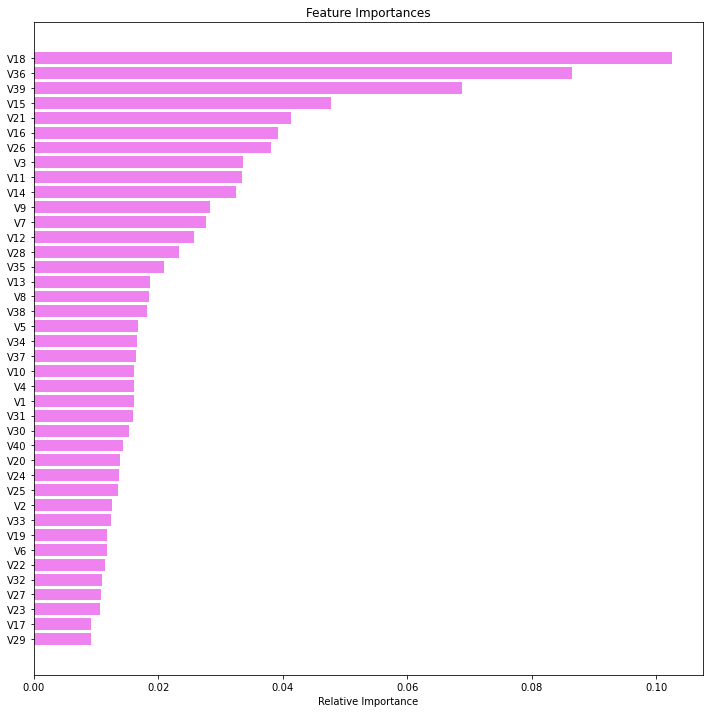

```python
feature_names = X.columns
importances = randfr_tuned1.feature_importances_
indices = np.argsort(importances)

plt.figure(figsize=(12, 12))
plt.title("Feature Importances")
plt.barh(range(len(indices)), importances[indices], color="violet", align="center")
plt.yticks(range(len(indices)), [feature_names[i] for i in indices])
plt.xlabel("Relative Importance")
plt.show()
```

1. All Variables has importance as shown from the chart above
2. However, V18, V36,v39,V15,V21 are the Top most 5 important predictors.

## Pipeline to Build Final Model

```python
# We have only numerical variables so we will just one pipeline
#Create List of variables
numerical_features = [
    "V1",
 "V2",
 "V3",
 "V4",
 "V5",
 "V6",
 "V7",
 "V8",
 "V9",
 "V10",
 "V11",
 "V12",
 "V13",
 "V14",
 "V15",
 "V16",
 "V17",
 "V18",
 "V19",
 "V20",
 "V21",
 "V22",
 "V23",
 "V24",
 "V25",
 "V26",
 "V27",
 "V28",
 "V29",
 "V30",
 "V31",
 "V32",
 "V33",
 "V34",
 "V35",
 "V36",
 "V37",
 "V38",
 "V39",
 "V40",
]

# creating a transformer for numerical variables, which will apply simple imputer on the numerical variables
numeric_transformer = Pipeline(steps=[("imputer", SimpleImputer(strategy="median"))])

#Pass into the column transformer
preprocessor = ColumnTransformer(
    transformers=[
        ("num", numeric_transformer, numerical_features),
    ],
    remainder="passthrough",
)
```

```python
# Creating new pipeline with best parameters
model = Pipeline(
    steps=[
        ("pre", preprocessor),
        (
            "RandomForest",
            RandomForestClassifier(

    n_estimators = 250,
    max_features='log2',
    max_samples=0.5000000000000001,
    min_samples_leaf=1,
            ),
        ),
    ]
)
# Fit the model on training data
model.fit(XT, yT)
```

```
Pipeline(steps=[('pre',
                 ColumnTransformer(remainder='passthrough',
                                   transformers=[('num',
                                                  Pipeline(steps=[('imputer',
                                                                   SimpleImputer(strategy='median'))]),
                                                  ['V1', 'V2', 'V3', 'V4', 'V5',
                                                   'V6', 'V7', 'V8', 'V9',
                                                   'V10', 'V11', 'V12', 'V13',
                                                   'V14', 'V15', 'V16', 'V17',
                                                   'V18', 'V19', 'V20', 'V21',
                                                   'V22', 'V23', 'V24', 'V25',
                                                   'V26', 'V27', 'V28', 'V29',
                                                   'V30', ...])])),
                ('RandomForest',
                 RandomForestClassifier(max_features='log2',
                                        max_samples=0.5000000000000001,
                                        n_estimators=250))])
```

```python
# Calculating different metrics on test set
RandomForest_random_test = model_performance_classification_sklearn(
    model, XT, yT
)
print("Testing performance:")
RandomForest_random_test
```

```
Testing performance:
```

[output not shown]

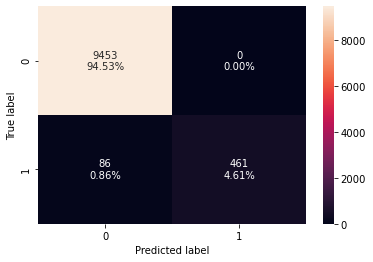

```python
# creating confusion matrix
confusion_matrix_sklearn(model, XT, yT)
```

```python
# transforming and predicting on test data
model.predict(XT)
```

```
array([0, 0, 0, ..., 0, 0, 0], dtype=int64)
```

#### Observations

# Recommendations and Conclusions

## Conclusions

1. Despite not knowing the names of the variables being used, it can be seen that not all variables carry a similar amount of weighting in determining the maintenance cost with the most important factors being V18, V36,v39,V15,V21

## Recommendations

1. Special focus should be given to the parts that have a higher rate of decomposition
2. Costs of equipment needs to be amortized in order to reduce the effect of the costs on the books